# Twitter Analysis Project on Nike and Adidas

12/18/2017

## Introduction

Nike and Adidas are two popular brands producing sport goods. Therefore, it may be interesting to see how people talk about these two brands in different ways. In this project, I will be analyzing the tweets using "nike"/"adidas" as hashtags. I will first compare their content. And I will see if the content of tweets related to a certain brand will change as time goes.

## Top 30 Most Frequent Words

I pulled out 5000 tweets that use #nike/#adidas as hashtags to carry out analysis on.

Nike

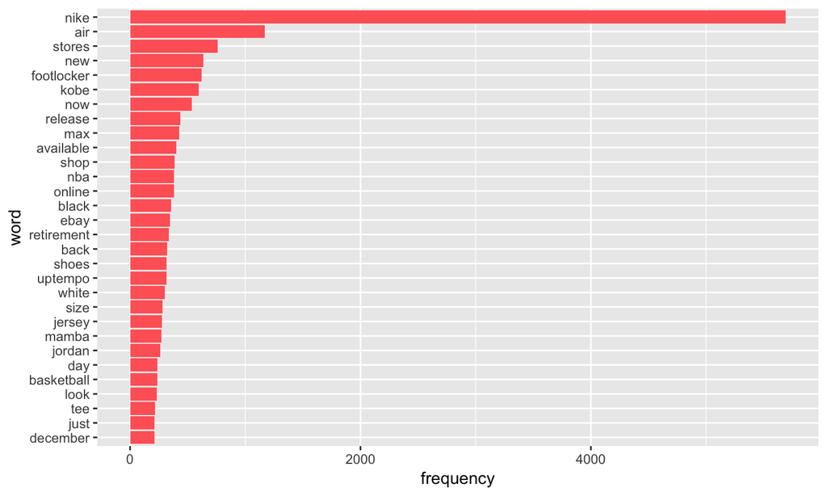

## Top 30 Most Frequent Words

### Adidas

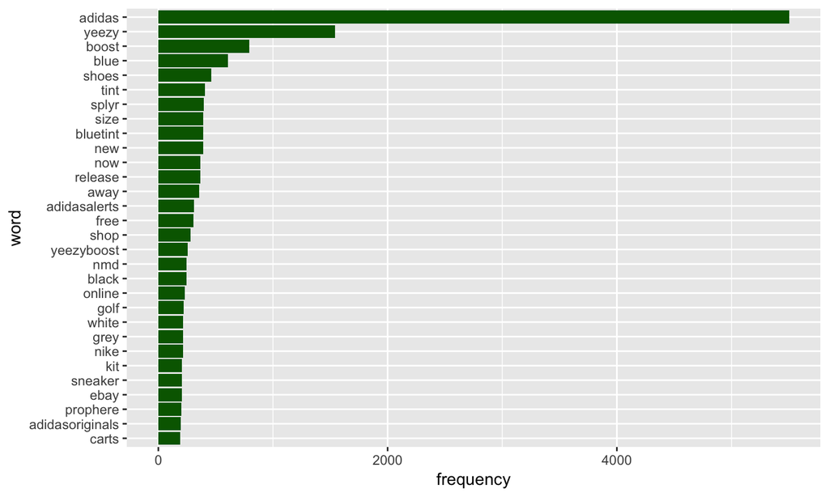

## Word Cloud

### Nike

[figure not shown]

## Word Cloud

### Adidas

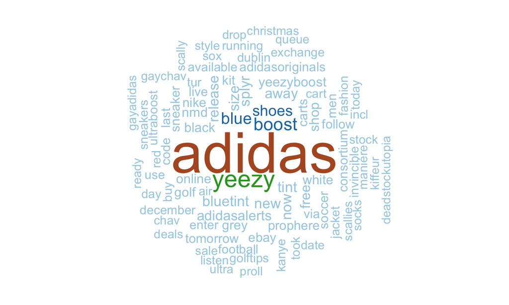

## Analysis

Here we can see most of the words are the names of products.They are mostly about the shoes and sport shirts of these two brands, which match the types of their popular products.

## Special Word

```
##          word frequency
## adidas adidas       126
```

```
##      word frequency
## nike nike       214
```

## Common Words

```
##      word pro_in_nike pro_in_adidas
## 1     new  0.03712770    0.02445464
## 2     now  0.03135746    0.02294587
## 3 release  0.02541237    0.02294587
## 4    ebay  0.02028327    0.01282454
```

We can see that the words "new","now","release" and "ebay" are all in the list of top 30 most frequent words of the tweets using "nike" and "adidas" hashtags. From the first three words, we can get the information that people like tweeting on product release of nike and adidas. Generally speaking, the proportion of these three words are higher for nike than adidas.

## Focus of Tweets

After looking for the meaning of the top 30 most frequent words,I categorized the words into five categories: clothes,shoe,product release,third-party platform and other.

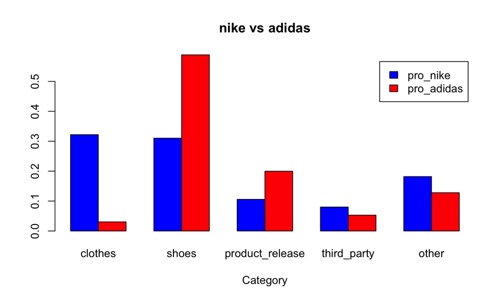

## Focus of Tweets

### Analysis

As we can see, the distributions look very different for the two brands. For tweets on products, adidas-related tweets focus much more on shoes than clothes while the distributions of shoe and shirt look pretty even for Nike. Therefore, we may say that people who tweet about adidas are muchn more interetsed in discussing its shoes than its clothes. And the interest on clothes and shoes of people who tweet about nike are pretty much the same. From this we can find out which kind of products of these two brands is more popular in people's discussion.

Also we can see that people who tweet about adidas care more about its product release than people who tweet about nike. From this we may infer that the product release of adidas attract more attention than nike's.

The proportion of tweets of nike about third-party platform is slightly higher than adidas'. This could be because the transactions of nike products on third-party platform are more common than adidas's.

## Frequent Words about Shoes

### Nike

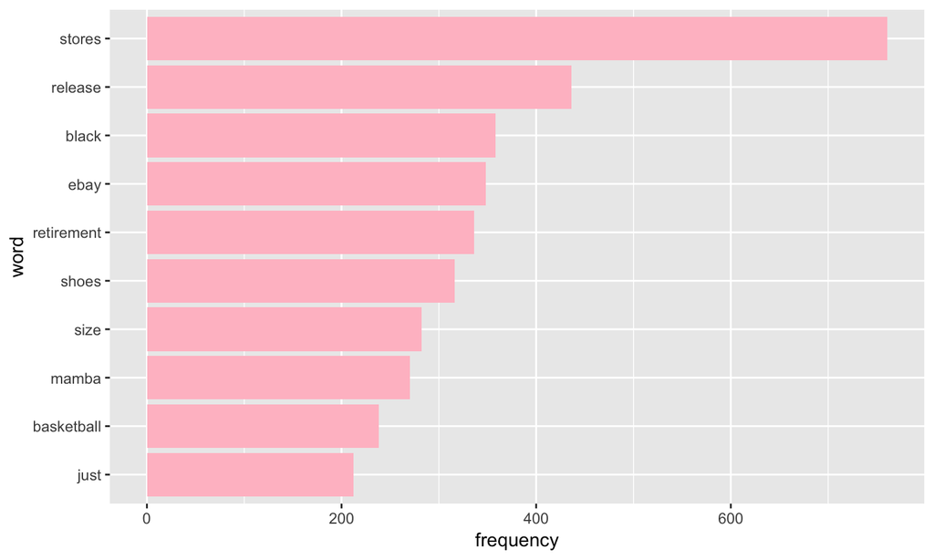

## Frequent Words about Shoes

### Adidas

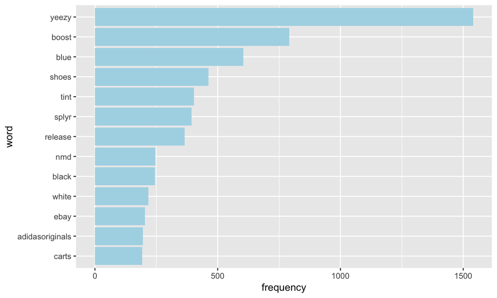

## Frequent Words about Shoes

### Analysis

The way that people mention the product may not seem important. But it actually reflects the expressions of products in their minds. For example, when people directly use the name of shoes to point to their interested shoes, they want to talk about that specific style, which corresponds to a specific function, apperance and even price. On the other hand, if people use color names to refer to shoes, it means that they just want to talk about shoes in that color without anything specific on their functions or other perspectives.

## Map Distribution

### Nike

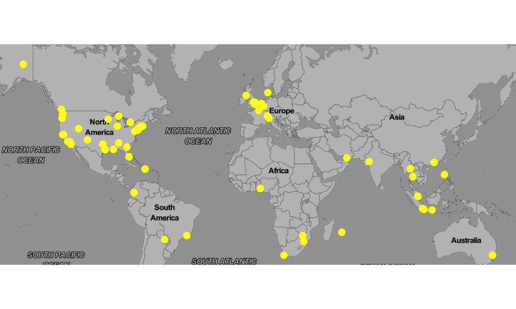

## Map Distribution

### Adidas

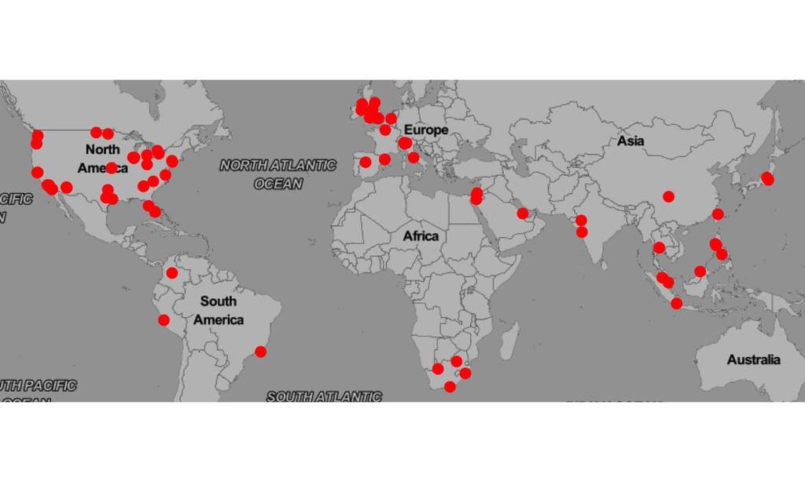

## Map Distribution

### Analysis

The map distribution of tweets related to nike/adidas are similar. Most of the tweets are posted by people in North America, which is reasonable because both nike and adidas are American brands. The second largest group locates on Western Europe, which also makes sense because nike and adidas are popular in Europe too. The rest are posted by people in Asia, Africa and South America, which are located pretty disperse without too much pattern.

## How Word Frequency Changes as Time Changes

### Assumption

Theoretically speaking, the attention on new product release will become higher as the time approches the release date. Here I would like to see if we can infer on any future release based on the the change of peoples' interest in December in 2017 by visualizing the change of word frequency of product release related words.

## How Word Frequency Changes as Time Changes

### Graphs

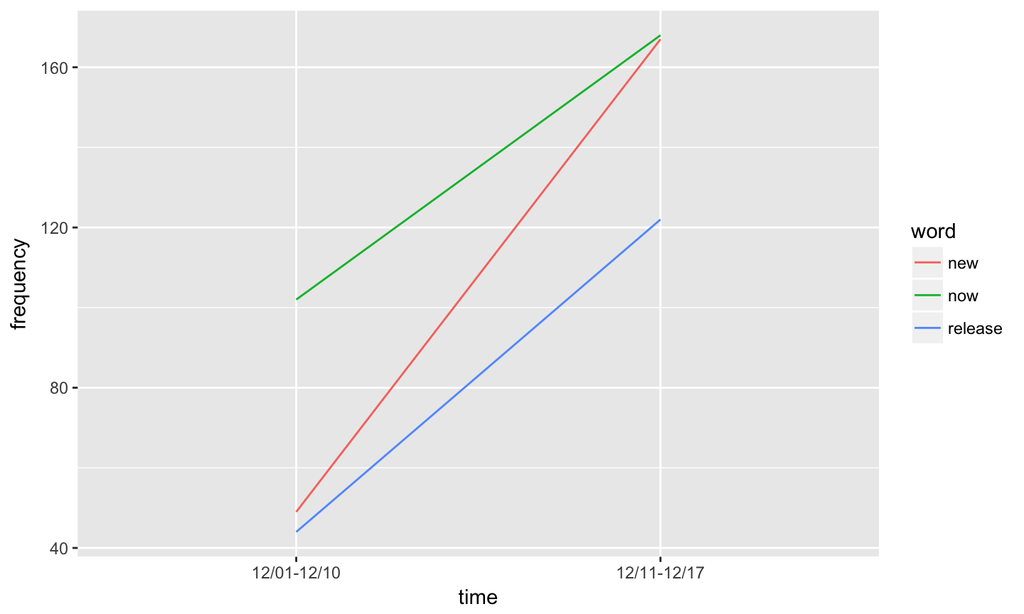

## How Word Frequency Changes as Time Changes

### Analysis

As we expect, the frequency of words–"new", "now" and "release" become much higher in the late December, from which we can assume that the release will be in the beginning of 2018. Nike did a successful advertising because people are talking about the release. This method could be used by companies to detect the change of people's interest on their new product. If there is not much change as the release date approches, the reason could be either the company doesn't do enough advertising so people don't know about it or the advertising is done so early compared with the release date that people's interest already faded.